# Quanto conta il prezzo su Steam?

## Analisi dei 1000 giochi più venduti

### marzo 2026

### *Gabriele Podda*

# Introduzione

## Perché i videogiochi?

- Appassionato ormai da 10 anni

## Perché Steam?

- Una delle principali piattaforme di distribuzione digitale di videogiochi per PC

## Domande

**[D1]** Fra i giochi a pagamento, quelli che costano di più hanno recensioni migliori?

**[D2]** Il punteggio delle recensioni varia fra i generi?

**[D3]** I free-to-play reggono ancora il confronto con i giochi a pagamento?

# I dati

## Fonte

- **Top 1000 Steam Games**, Kaggle, marzo 2026
- costruito da Steam Storefront API e SteamSpy API

## Contenuto

- **Cosa c'è**: prezzo, genere, dati su recensioni e players count (24 hrs)
- **Cosa manca**: vendite effettive, e solo il picco di un giorno anziché una media

## Due colonne da correggere

### Il dataset dichiara i **possessori** di ogni gioco

Il rapporto con il numero di recensioni vale **esattamente 30,0** su tutte e 898 le righe valide.

`possessori = recensioni × 30`

### Il prezzo registrato era quello **del giorno**

**342 titoli su 1000** erano in saldo al momento della raccolta. Ricostruisco il listino:

`prezzo ÷ (1 − sconto)`.

## **[D1]** Fra i giochi a pagamento, quelli che costano di più hanno recensioni migliori?

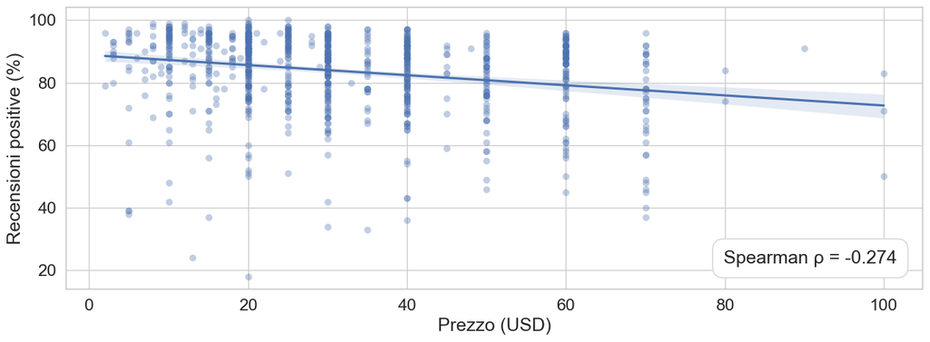

**Spearman = −0,27**: all'aumentare del prezzo il gradimento tende a scendere, ma debolmente

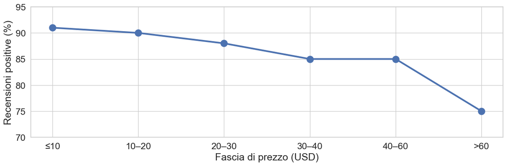

### No, anzi il contrario

dal **91%** sotto i 10 $ al **75%** sopra i 60 $

## **[D2]** Il punteggio delle recensioni varia fra i generi?

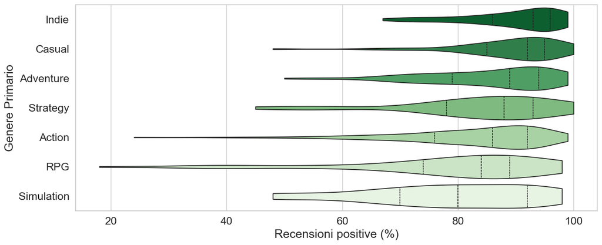

### Sì, di 13 punti percentuali

dall'**80%** di *Simulation* al **93%** di *Indie*

## **[D3]** I free-to-play reggono ancora il confronto con i giochi a pagamento?

### "Reggere" può voler dire due cose

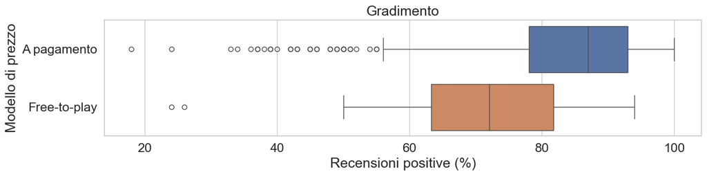

### Gradimento: **no**

mediana **72%** contro **87%**

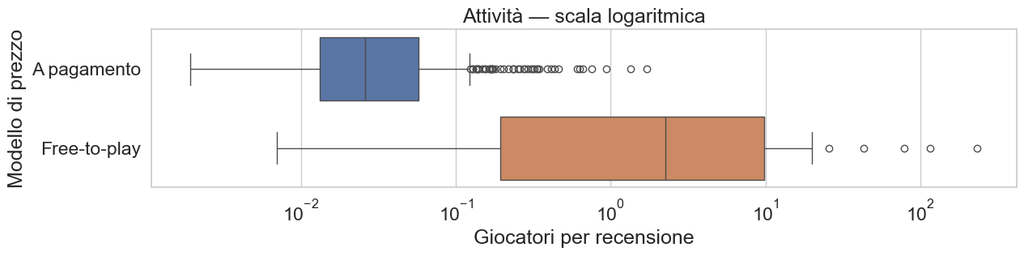

### Attività: **sì**

mediana **87 volte** superiore

# Risposte

### 1. I giochi che costano di più hanno recensioni migliori?

No. Si passa dal **91%** dei titoli sotto i 10 $ al **75%** di quelli sopra i 60, ma la relazione resta debole.

### 2. Il punteggio varia fra i generi?

Sì, di **tredici** punti percentuali: dall'**80%** di *Simulation* al **93%** di *Indie*.

### 3. I free-to-play reggono ancora?

Dipende da cosa si misura: sono valutati **quindici** punti sotto, ma a parità di pubblico hanno **87** volte più giocatori attivi.